# 项目：IMDb电影数据集初步分析

## 目录

- 简介
- 数据整理
- 探索性数据分析
- 结论

## 简介

> 本数据集为经过清洗的数据集，原始数据来自Kaggle。本数据集中包含 1 万条电影信息，信息来源为“电影数据库”（TMDb，The Movie Database），包括用户评分和票房。“演职人员 (cast)”、“电影类别 (genres)”等数据列包含由竖线字符（|）分隔的多个数值。“演职人员 (cast) ”列中有一些奇怪的字符。先不要清洁它们，你可以保持原样，不去管它们。以“_adj”结尾的最后两列表示了考虑了通货膨胀之后的相关电影的预算和收入（以2010年美元的价值来计算）。

> 本次要探索的初步问题为：
> 1. 什么类型的电影票房收入最高
> 2. 电影的流行度对电影票房的收入有什么影响
> 3. 电影的评分对票房收入有什么影响

```python
import pandas as pd
import numpy as np
import matplotlib.pyplot as plt
%matplotlib inline

df_movies = pd.read_csv('tmdb_movies.csv')
```

## 1.评估数据集

### 1.1 常规属性

先打印数据集的前几行，了解下数据集

```python
df_movies.head(3)
```

|  | id | imdb_id | popularity | budget | revenue | original_title | cast | homepage | director | tagline | ... | overview | runtime | genres | production_companies | release_date | vote_count | vote_average | release_year | budget_adj | revenue_adj |
| --- | --- | --- | --- | --- | --- | --- | --- | --- | --- | --- | --- | --- | --- | --- | --- | --- | --- | --- | --- | --- | --- |
| 0 | 135397 | tt0369610 | 32.985763 | 150000000 | 1513528810 | Jurassic World | Chris Pratt\|Bryce Dallas Howard\|Irrfan Khan\|Vi... | http://www.jurassicworld.com/ | Colin Trevorrow | The park is open. | ... | Twenty-two years after the events of Jurassic ... | 124 | Action\|Adventure\|Science Fiction\|Thriller | Universal Studios\|Amblin Entertainment\|Legenda... | 6/9/15 | 5562 | 6.5 | 2015 | 1.379999e+08 | 1.392446e+09 |
| 1 | 76341 | tt1392190 | 28.419936 | 150000000 | 378436354 | Mad Max: Fury Road | Tom Hardy\|Charlize Theron\|Hugh Keays-Byrne\|Nic... | http://www.madmaxmovie.com/ | George Miller | What a Lovely Day. | ... | An apocalyptic story set in the furthest reach... | 120 | Action\|Adventure\|Science Fiction\|Thriller | Village Roadshow Pictures\|Kennedy Miller Produ... | 5/13/15 | 6185 | 7.1 | 2015 | 1.379999e+08 | 3.481613e+08 |
| 2 | 262500 | tt2908446 | 13.112507 | 110000000 | 295238201 | Insurgent | Shailene Woodley\|Theo James\|Kate Winslet\|Ansel... | http://www.thedivergentseries.movie/#insurgent | Robert Schwentke | One Choice Can Destroy You | ... | Beatrice Prior must confront her inner demons ... | 119 | Adventure\|Science Fiction\|Thriller | Summit Entertainment\|Mandeville Films\|Red Wago... | 3/18/15 | 2480 | 6.3 | 2015 | 1.012000e+08 | 2.716190e+08 |

3 rows × 21 columns

1） 查看数据行数与列数

```python
df_movies.shape
```

```
(10866, 21)
```

由上面可知，数据有10866行，21列

2） 查看数据有哪些列

```python
df_movies.dtypes
```

```
id                        int64
imdb_id                  object
popularity              float64
budget                    int64
revenue                   int64
original_title           object
cast                     object
homepage                 object
director                 object
tagline                  object
keywords                 object
overview                 object
runtime                   int64
genres                   object
production_companies     object
release_date             object
vote_count                int64
vote_average            float64
release_year              int64
budget_adj              float64
revenue_adj             float64
dtype: object
```

由上面可知，各列的含义及数据类型为： 1) id，整数 2) imdb的id，字符 3) 流行度，浮点 4) 电影预算，整型 5) 票房收入，整型 6) 原始名称，字符 7) 主角，字符 8) 主页，字符 9) 导演，字符 10) 标题语，字符 11) 关键词，字符 12) 概述，字符 13) 电影时长，整型 14) 类型，字符 15) 制片公司，字符 16) 放映日期，字符 17) 打分数，整型 18) 均分，浮点 19) 上映年份，整型 20) 通货膨胀计算后的电影预算,浮点 21) 通货膨胀计算后的票房收入，浮点

3） 查看数据中有无重复、缺失项目

```python
df_movies.duplicated().sum()
```

```
1
```

数据集中以一条重复数据，查看具体哪条数据重复：

```python
df_duplicate = df_movies[df_movies.duplicated() == True]
df_duplicate
```

|  | id | imdb_id | popularity | budget | revenue | original_title | cast | homepage | director | tagline | ... | overview | runtime | genres | production_companies | release_date | vote_count | vote_average | release_year | budget_adj | revenue_adj |
| --- | --- | --- | --- | --- | --- | --- | --- | --- | --- | --- | --- | --- | --- | --- | --- | --- | --- | --- | --- | --- | --- |
| 2090 | 42194 | tt0411951 | 0.59643 | 30000000 | 967000 | TEKKEN | Jon Foo\|Kelly Overton\|Cary-Hiroyuki Tagawa\|Ian... | NaN | Dwight H. Little | Survival is no game | ... | In the year of 2039, after World Wars destroy ... | 92 | Crime\|Drama\|Action\|Thriller\|Science Fiction | Namco\|Light Song Films | 3/20/10 | 110 | 5.0 | 2010 | 30000000.0 | 967000.0 |

1 rows × 21 columns

```python
df_movies.isnull().sum()
```

```
id                         0
imdb_id                   10
popularity                 0
budget                     0
revenue                    0
original_title             0
cast                      76
homepage                7930
director                  44
tagline                 2824
keywords                1493
overview                   4
runtime                    0
genres                    23
production_companies    1030
release_date               0
vote_count                 0
vote_average               0
release_year               0
budget_adj                 0
revenue_adj                0
dtype: int64
```

由上面结果可以知道，数据集中有一行重复；另外，imbd_id、主演、主页、导演、标题语、关键词、总评、类型、制片公司等9列有缺失数据，缺失行数分别为10、76、7930、44、2824、1493、4、23、1030

### 1.2 数据清理

1) 丢弃重复数据

```python
df_movies = df_movies.drop_duplicates()
```

```python
df_movies.shape
```

```
(10865, 21)
```

除了类型这一列外，其他imbd_id、主演、主页、导演、标题语、关键词、总评、制片公司等列对我们研究的问题没有影响，因此接下来仅仅删除genres缺失的行。

```python
df_movies = df_movies.dropna(subset = ['genres'])
```

```python
df_movies.shape
```

```
(10842, 21)
```

```python
df_generes = df_movies['genres'].str.split('|', expand=True)
df_generes.head(5)
```

|  | 0 | 1 | 2 | 3 | 4 |
| --- | --- | --- | --- | --- | --- |
| 0 | Action | Adventure | Science Fiction | Thriller | None |
| 1 | Action | Adventure | Science Fiction | Thriller | None |
| 2 | Adventure | Science Fiction | Thriller | None | None |
| 3 | Action | Adventure | Science Fiction | Fantasy | None |
| 4 | Action | Crime | Thriller | None | None |

由于每个电影有多种类型，这里将同一部电影的数据根据类型分为多条数据。每条数据只包含一个电影类型。

```python
df_new = df_movies.drop('genres', axis=1).join(
        df_movies['genres'].str.split('|', expand=True).stack().reset_index(level=1, drop=True).rename('genres'))
```

```python
df_new.shape
```

```
(26955, 21)
```

```python
df_new.head(1)
```

|  | id | imdb_id | popularity | budget | revenue | original_title | cast | homepage | director | tagline | ... | overview | runtime | production_companies | release_date | vote_count | vote_average | release_year | budget_adj | revenue_adj | genres |
| --- | --- | --- | --- | --- | --- | --- | --- | --- | --- | --- | --- | --- | --- | --- | --- | --- | --- | --- | --- | --- | --- |
| 0 | 135397 | tt0369610 | 32.985763 | 150000000 | 1513528810 | Jurassic World | Chris Pratt\|Bryce Dallas Howard\|Irrfan Khan\|Vi... | http://www.jurassicworld.com/ | Colin Trevorrow | The park is open. | ... | Twenty-two years after the events of Jurassic ... | 124 | Universal Studios\|Amblin Entertainment\|Legenda... | 6/9/15 | 5562 | 6.5 | 2015 | 1.379999e+08 | 1.392446e+09 | Action |

1 rows × 21 columns

```python
df_filter = df_new[['original_title','popularity', 'vote_average', 'genres', 'release_year', 'revenue_adj']]
df_filter.head(10)
```

|  | original_title | popularity | vote_average | genres | release_year | revenue_adj |
| --- | --- | --- | --- | --- | --- | --- |
| 0 | Jurassic World | 32.985763 | 6.5 | Action | 2015 | 1.392446e+09 |
| 0 | Jurassic World | 32.985763 | 6.5 | Adventure | 2015 | 1.392446e+09 |
| 0 | Jurassic World | 32.985763 | 6.5 | Science Fiction | 2015 | 1.392446e+09 |
| 0 | Jurassic World | 32.985763 | 6.5 | Thriller | 2015 | 1.392446e+09 |
| 1 | Mad Max: Fury Road | 28.419936 | 7.1 | Action | 2015 | 3.481613e+08 |
| 1 | Mad Max: Fury Road | 28.419936 | 7.1 | Adventure | 2015 | 3.481613e+08 |
| 1 | Mad Max: Fury Road | 28.419936 | 7.1 | Science Fiction | 2015 | 3.481613e+08 |
| 1 | Mad Max: Fury Road | 28.419936 | 7.1 | Thriller | 2015 | 3.481613e+08 |
| 2 | Insurgent | 13.112507 | 6.3 | Adventure | 2015 | 2.716190e+08 |
| 2 | Insurgent | 13.112507 | 6.3 | Science Fiction | 2015 | 2.716190e+08 |

## 2. 探索性数据分析

### 2.1 什么类型的电影票房收入最高

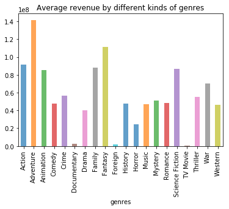

```python
df_filter.groupby('genres')['revenue_adj'].mean().plot(kind='bar', title='Average revenue by different kinds of genres', alpha=0.7)
```

### 2.2 电影的流行度对电影票房的收入有什么影响？

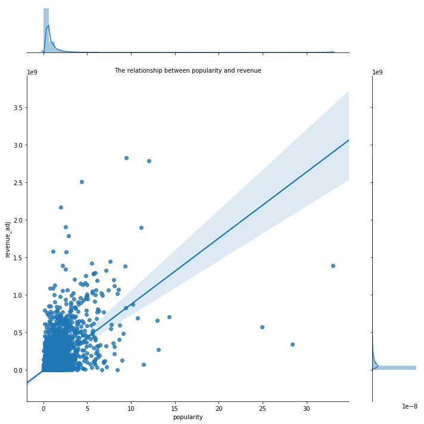

```python
import seaborn as sns
sns.jointplot(data=df_movies, y='revenue_adj', x='popularity', kind="reg", size=10, space=0.5)
plt.title('The relationship between popularity and revenue',fontsize=10)
plt.show()
```

### 2.3 电影的评分对票房收入有什么影响

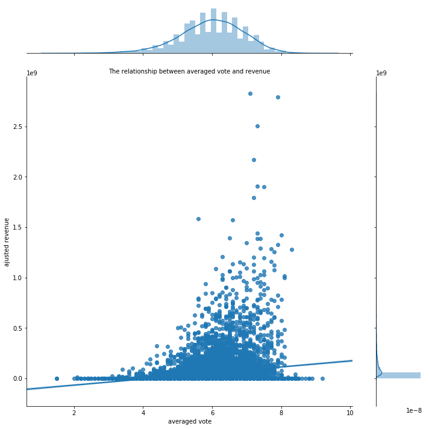

```python
sns.jointplot(data=df_movies, y='revenue_adj', x='vote_average', kind="reg", size=10, space=0.5)
plt.title('The relationship between averaged vote and revenue',fontsize=10)
plt.xlabel('averaged vote')
plt.ylabel('ajusted revenue')
plt.show()
```

由上图可知，票房收入和评分之间并不是线性关系。评分基本呈正态分布，而收入呈偏态分布：低票房收入的电影较多。总的来说，评分特别高的电影(8分以上)，和评分特别低的电影（5分以下），它们的票房收入都不太理想。而评分在7分左右的电影，其票房是最高的。

## 3. 结论

最后，电影评分与票房收入也不是成线性关系。评分在7上下的电影，平均票房收入最高。而评分在8以上的电影，平均票房收入较低。这种现象较为奇特。一种可能的解释是，电影的打分由专业人员和普通人员一起构成。一部流传度很好的电影，往往在艺术性和商业性之间做了一些妥协，因此，剧情方面和艺术性方面就中规中矩。而评分较高的电影，往往剧情性和艺术性较强，但是较强的艺术性也意味着一定的观影门槛，并不能引起所有人的兴趣，导致在传播性方面就会差一点。